# Welcome to Intro to Comp Bio

[figure not shown]

[aub.ie/icb](https://phyletica.org/intro-to-comp-bio/)

## Today’s objectives

- What is Comp Bio?
- Course overview
- Exercise 1
  - Starting to setup ASC account

# The Instructional Team

## GTAs

- Sean Onileowo (sao0027)
- Alex Systun (ats0100)
- Kyndall Skelton (kps0016)

## Instructor

[Dr. Jamie Oaks](http://phyletica.org)

phyletica.org | GitHub: joaks1

## Phyletica Lab Research

[figure not shown]

# What is Comp Bio?

*Computational biology*

- The study of life using computational techniques, theoretical models, and data
- Conceptual

*Bioinformatics*

- Creating tools (algorithms, databases) to solve biological problems
- More applied

## Comp Bio is as broad as biology

- All fields of biology can now generate enormous quantities of data that require computational approaches
- For this class, we will focus on:
  - Evolutionary biology
  - Molecular evolution & phylogenetics
  - Genomics
- Modeling and computational skills generalize to other fields

## Algos & models used in comp bio

A *model* is a parametric explanation of biological observations

An *algorithm* is a set of instructions for solving a problem

## Probabilistic models

- Maximum likelihood
- Bayesian inference
- Machine learning
- Markov chain models

Used across biology

## Algorithms

- String algos
  - sort, search, etc
- Optimization algos
  - Dynamic programming
  - Linear programming
  - Greedy algos, heuristic methods
  - Expectation-maximization

Used across biology

## Science is based on models

> All science is based on models, and every scientific model comprises three distinct stages: statement of well-defined hypotheses; deduction of all the consequences of these hypotheses, and nothing but these consequences; confrontation of these consequences with observed data. - Maurice Allais

> All models are wrong, but some models are useful. - George Box

# Course overview

## Course format

- This course will be in-person
- We will do a mix of
  - Lecture
  - “Follow-along” demos
  - Exercises
- I will record classes as Panopto webcasts and post them to Canvas
  - BUT, this will not replace exercises

## Course objectives

Enable you to:

- Apply basic Linux/Unix command-line utilities
- Use basic programming for data processing
- Use version-control tools for reproducibility
- Understand probabilistic models for biological questions
- Encode and apply computational algorithms to biological data

*Learn computational approaches to processing biological data and modeling biological ideas*

## Course materials

- You will need a computer you can bring to class with you
  - Laptop/tablet running Linux, macOS, or Windows is ideal
  - Up-to-date browser
- A free [GitHub](https://github.com/) account
- A free [Marimo molab](https://molab.marimo.io/) account

## Course content

Found on the course

- [Website](https://phyletica.org/intro-to-comp-bio/)
  - Slides & documentation
  - Exercises
- Canvas page
  - Syllabus
  - Announcements
  - Some exercises
  - Assignment submission

## Textbook

- There is no required textbook
- Practical Computing for Biologists, by Haddock and Dunn, is a good resource
- I might distribute readings throughout the semester

## Office hours

- GTAs and I will setup booking pages in Outlook
  - [Here’s mine](https://outlook.office.com/bookwithme/user/08127dcfceae4c999e18fa0c0a629d44@auburn.edu/meetingtype/WN-JhsVWeEeLrmmxWMNwLA2?anonymous&ismsaljsauthenabled&ep=mlink)
- Use these to book 30-minute appointments with us
  - 1-on-1 meetings are ideal for computational topics

## Where’s Dr. Oaks?

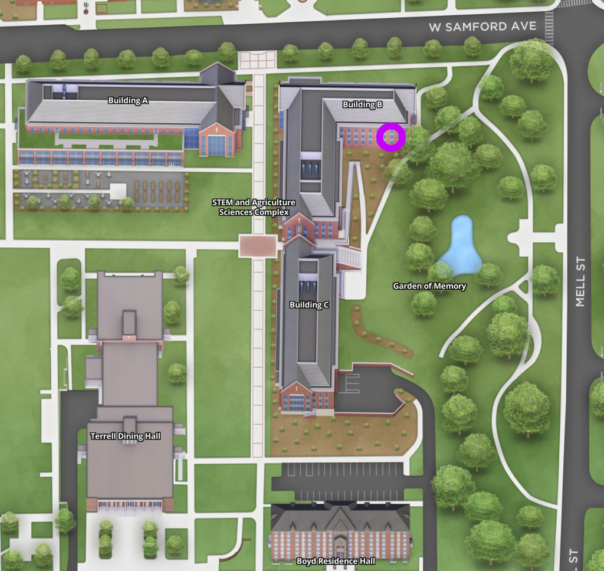

STEM-Ag 2238

# Assignments & Grading

## My philosophy for high-level courses

- I assume you’re here for the right reasons
- If so, I think you’ll have fun and learn a lot
- At your stage, you should be motivated to acquire knowledge and skills
  - Not by grades
- Can you get a good grade without learning much?
  - Quite possibly

## Lab exercises

- Low-stake opportunities to apply what you’re learning
- Mostly completed in class
- Work together, but submit your own work
- Graded for effort
- We will do a number of these and your 2 lowest scores will be dropped

## Capstone projects

- Similar in format to exercises, but more challenging
- Do not work together
- Graded for correctness
- Mostly done out of class, but you will have opportunities to work on them in class
- Start early and use office hours

## Late exercises and projects

- 20% deduction per day late

## Course grading

Table 1: Breakdown of grading component percentages

| Item | Grade % |
| --- | --- |
| Lab exercises | 60% |
| Capstone projects | 40% |

Your final percentage will be calculated as:

Final percent = ( lab exercises % $\times$ 0.6 )

$+$ ( capstone projects % $\times$ 0.4 )

## Grading scale

Table 2: Grading scale

| Percentage | Grade |
| --- | --- |
| $\geq$ 90% | A |
| 80.0 – 90.0% | B |
| 70.0 – 80.0% | C |
| 60.0 – 70.0% | D |
| < 60.0% | F |

# Course policies

(see syllabus)

## AI policy

- I will not teach it, but you are encouraged to try out generative AI tools
- Use them to help (not hinder) your learning
- When used, you need to disclose

## Class courtesy

- It’s our shared responsibility to create a positive learning environment for everyone
- Please use the “Anonymous Feedback” module in Canvas to report any issues

# Exercise 1

## Make sure your VPN is setup and working

- Connect to AU’s VPN
- Open browser and go to: https://csm-earth.auburn.edu/
- You should see log-in page
- Don’t log in now, we will do that on Wednesday
- If you can’t see the log-in page, your VPN is not working
  - Let us know
  - Reach out to [AU IT Service Desk](https://auburn.service-now.com/it?id=sc_cat_item&sys_id=d42cfd0cdbcd2340965cf9b9af961928)

[figure not shown]

## Setting up ASC account

- You should have received a Canvas message with your username and password for the ASC
  - Please let me know if you didn’t
- Go to the “Exercise-01” Module on Canvas and use the “Setting-up-DUO-for-ASC-account.pdf” PDF to:
  - Set up 2-factor authentication for your ASC account
  - Access the ASC user documentation
  - From “Getting started” page, read:
    - *About this website*
    - *Rules of behavior*
    - *Getting help*
- Then, answer the questions for the “Exercise 1” quiz
- Due before class next Monday

# Coming up

## Wednesday

- Intro to command-line shell environment
- Access Linux Thinlinc environment
  - COSAM IT will be on-hand to help troubleshoot